# activites_2_key

Christopher Loan

2023-01-26

# Section 0: Set seed

Set a seed at `022023`

```r
set.seed(022023)
```

# Section 1: Fit Random Forest to `ptitanic` Dataset

## Section 1.1: load packages

Load these packages with `library()`

1. `tidyverse`
2. `rsample`
3. `rpart.plot`
4. `ranger`
5. `missRanger`
6. `vip`

If you did not install these already, you’ll have to install each of these with the `install.packages()` function. e.g., `install.packages('tidyverse')` etc.

```r
# data manipulation
library(tidyverse)
# setting up data: training / testing
library(rsample)
# for the data
library(rpart.plot)
# random forests
library(ranger)
# imputing data
library(missRanger)
# variable importance plots
library(vip)
```

## Section 1.2: set up data

### 1.2.1: load data

load the `ptitanic` data from the `rpart.plot` package.

```r
data(ptitanic)
```

### Section 1.2.2: set reference group for outcome

Use `relevel()` to ensure `died` is the reference group in the `ptitanic` dataset.

```r
ptitanic <-
  ptitanic %>%
  mutate(
    survived = relevel(survived, ref = 'died')
  )
```

### Section 1.2.3: impute the missing values

Good imputation practices are beyond the scope of the workshop, but let’s just do a quick imputation so we do not have missing data.

This is important only because `ranger()` does not handle missing data by default.

Run the following code to impute with `missRanger()`:

```r
ptitanic <- missRanger::missRanger(ptitanic, pmm.k=1)
```

```
##
## Missing value imputation by random forests
##
##   Variables to impute:       age
##   Variables used to impute:  pclass, survived, sex, age, sibsp, parch
## iter 1:  .
## iter 2:  .
## iter 3:  .
## iter 4:  .
```

**NOTE:** If you get stuck here for some reason, make sure `missRanger` is installed. If that still does not work, you can use this code instead

```r
ptitanic <- ptitanic %>% drop_na(age)
```

### Section 1.2.4: split data

Use `rsample` to split the data into training and testing sets.

```r
split_data <- initial_split(ptitanic)
training_data <- training(split_data)
testing_data <- testing(split_data)
```

## Section 1.3: Fit a Random Forest

Predict `survived` with all other variables in the dataset

Be sure to set `importance = 'impurity'`. Using the help documentation, explain what this does in your own words.

**Hint:** there are 2 ways to include all variables:

- One is simply listing all of them, separated with `+` symbols.
- The other is a shortcut where you list the outcome, a tilde, then a period (`.`): `outcome_name ~ .`

```r
all_vars_RF <-
  ranger(
    survived ~ .,
    data = training_data,
    importance = 'impurity'
    )
```

## Section 1.4: Explore the model

### Section 1.4.1: Look at the structure

print the tree object (i.e., just run the name of the stored model).

```r
all_vars_RF
```

```
## Ranger result
##
## Call:
##  ranger(survived ~ ., data = training_data, importance = "impurity")
##
## Type:                             Classification
## Number of trees:                  500
## Sample size:                      981
## Number of independent variables:  5
## Mtry:                             2
## Target node size:                 1
## Variable importance mode:         impurity
## Splitrule:                        gini
## OOB prediction error:             16.72 %
```

In your own words, what does out-of-bag prediction error mean?

What is the OOB prediction error in this dataset?

**Hint:** remember we’re predicting a dichotomous variable, so we’re doing classification

How many decision trees are in this random forest?

#### Section 1.4.2

Use `vip()` to visualize the variable importance plot for the random forest

If you see the following error, be sure to add `importance = 'impurity'` into the `ranger()` call above:

```
Error in importance.ranger(object) :
  No variable importance found. Please use 'importance' option when growing the forest.
```

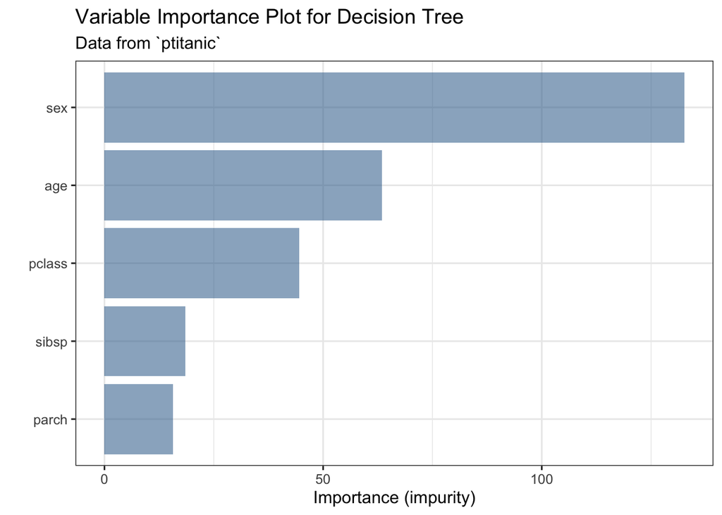

```r
vip(
  all_vars_RF,
  include_type = TRUE
) +
  theme_bw(base_size = 12) +
  labs(
    title = 'Variable Importance Plot for Decision Tree',
    subtitle = 'Data from `ptitanic`',
  ) +
  aes(fill = 1, alpha = 0.3) +
  theme(legend.position = 'none')
```

### Section 1.5: Evaluate Model Performance (unseen data)

Use your withheld testing data to determine the percent of new predictions that are correct.

```r
accuracy_percentages <-
  testing_data %>%
  mutate(
    predicted =
      predict(
        all_vars_RF,
        data = .,
        )$prediction,
    actual = survived,
    prediction_accuracy =
      if_else(
        actual == predicted,
        'Correct',
        'Incorrect'
        )
  ) %>%
  count(prediction_accuracy) %>%
  mutate(
    percent =
      paste0(
        round(
          (n / sum(n))* 100),
        '%'
        )
  )
```

```r
accuracy_percentages
```

```
##   prediction_accuracy   n percent
## 1             Correct 257     78%
## 2           Incorrect  71     22%
```

When done, return your focus to the presentation